# Pathview

Deepthi

31/12/2020

# Pathview

Pathview is an independent software package for pathway based data integration and visualization.Pathview has four functional modules the Downloader, Parser, Mapper and viewer.Pathview plots and displays user data on to their respective pathways. (Luo and Brouwer 2013)

## Introduction

The pathway solutions are used in NGS sequencing data analysis.Its has been frequently applied to gene expression, GWAS, proteomics and metagenomics.Pathway analysis is more delicate,repeatable and descriptive when compared to individual gene approach.Several pathway analysis methods and data types are introduced in R/Bioconductor but nothing is devoted for pathway data integration. A new package called pathview is used for data integration and visualization.It has three aspects 1.Available and functional pathways 2.Data integration capacity 3.Easy to automate and merge with pathway evaluation tools.

## Methods

Pathview package can be divided into 4 functional modules Downloader, Parser, Mapper and Viewer.

### Data Visualization

It produces both KEGG view and Graphiz view for pathways.Both graph systems are easy to understand and design.They can allow changes to nodes and edges to KEGG view. KEGG view can be available for all metadata for all tissues, cells , input and output connections, which is important for understanding and analysis of pathway biology.

### Automated and integrated Analysis

Pathview is an open source, error free computer program.So it is used to merge pathways to gene expression.pathview can integrate with broad range of reliable tools presenting to the R/Bioconductor for sequencing data and pathway analysis.This package analysis also integrates with another package called GAGE in bioconductor. In pathview they use heat maps, scatter plots/line plots to visualize perturbation patterns.These plots are easy to generated in groups.The graphs are generated in a structured way for both classical and line plots.Thus improving the analysis and explanation of NGS molecular data. KEGG XML data files has small insufficiencies, incompatible and error records due to manual correction. Pathview parser rights the incorrect KEGG codes to enzyme-compound reactions by integrating with the Ecrel Record of reactions.Pathview utilizes KEGG graph package to parse KEGG data files.

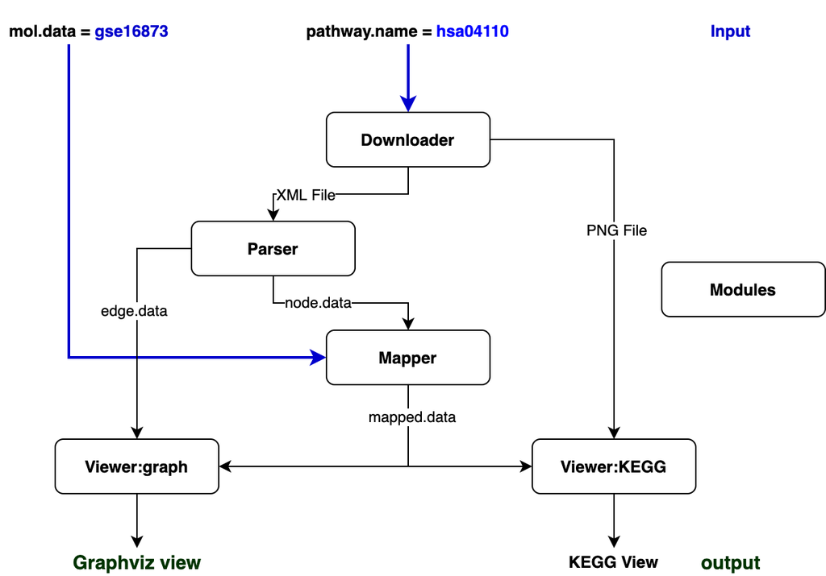

## Discussion

pathview produces results in the form of pathway graphs or pictures which are human readable, easy to understand. It works with broad range of data types, IDs and formats.It can be easily merged with other tools for perfect pathway analysis.It works well with all formats available in KEGG pathways.

## Results

The results obtained here are related to gene gse16873 is a Microarray data from breast cancer. Its pathways related to gene are involved in cell cycle with pathway ID hsa04110 and propionate metabolism in form pictures in KEGG view as PNG file format and Graphiz view as PDF file formats.We also integrated and visualized both gene data and compound data with metabolic pathways.

### Installation of pathview package

```r
if (!requireNamespace("BiocManager", quietly=TRUE))
install.packages("BiocManager")
BiocManager::install("pathview")
```

### Data Visualisation using pathview package

```r
# All defaults
library(pathview) # load Pathview package
```

```r
library(knitr)    # For knitting document and include_graphics fuction
library(ggplot2)  # For plotting
library(png)      # For grabbing  the dimensions of png files
data(gse16873.d)  #Gene id
data(demo.paths)  # pathways related to user gene &  illustrated  3 pathways
data(paths.hsa)   # hsa stand for humans
head(paths.hsa,3) # first 3 pathways are displayed
```

```
##                       hsa00010                       hsa00020
## "Glycolysis / Gluconeogenesis"    "Citrate cycle (TCA cycle)"
##                       hsa00030
##    "Pentose phosphate pathway"
```

```r
### kegg.native gives basic KEGG native pathway
i <- 1
pv.out <- pathview(gene.data = gse16873.d[, 1], pathway.id = demo.paths$sel.paths[i],
                   species = "hsa", out.suffix = "gse16873", kegg.native = T)
```

```
## Info: Working in directory /Users/deepthi/pathview_code
```

```
## Info: Writing image file hsa04110.gse16873.png
```

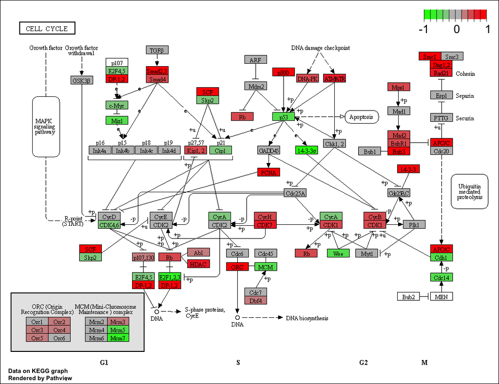

```r
img1_path <- "hsa04110.gse16873.png"
img1 <- readPNG(img1_path, native = TRUE, info = TRUE)
include_graphics(img1_path)
```

```r
list.files(pattern="hsa04110", full.names=T)
```

```
## [1] "./hsa04110.gse16873.2layer.pdf"
## [2] "./hsa04110.gse16873.2layer.png"
## [3] "./hsa04110.gse16873.pdf"
## [4] "./hsa04110.gse16873.png"
## [5] "./hsa04110.gse16873.split.expanded.pdf"
## [6] "./hsa04110.gse16873.split.pdf"
## [7] "./hsa04110.png"
## [8] "./hsa04110.xml"
```

```r
str(pv.out)
```

```
## List of 2
##  $ plot.data.gene:'data.frame':  92 obs. of  10 variables:
##   ..$ kegg.names: chr [1:92] "1029" "51343" "4171" "4998" ...
##   ..$ labels    : chr [1:92] "CDKN2A" "FZR1" "MCM2" "ORC1" ...
##   ..$ all.mapped: chr [1:92] "1029" "51343" "4171,4172,4173,4174,4175,4176" "4998,4999,5000,5001,23594,23595" ...
##   ..$ type      : chr [1:92] "gene" "gene" "gene" "gene" ...
##   ..$ x         : num [1:92] 532 919 553 494 919 919 188 432 123 77 ...
##   ..$ y         : num [1:92] 124 536 556 556 297 519 519 191 704 687 ...
##   ..$ width     : num [1:92] 46 46 46 46 46 46 46 46 46 46 ...
##   ..$ height    : num [1:92] 17 17 17 17 17 17 17 17 17 17 ...
##   ..$ mol.data  : num [1:92] 0.129 -0.404 -0.42 0.986 1.181 ...
##   ..$ mol.col   : chr [1:92] "#BEBEBE" "#5FDF5F" "#5FDF5F" "#FF0000" ...
##  $ plot.data.cpd : NULL
```

```r
head(pv.out$plot.data.gene)
```

```
##   kegg.names labels                            all.mapped type   x   y width
## 4       1029 CDKN2A                                  1029 gene 532 124    46
## 5      51343   FZR1                                 51343 gene 919 536    46
## 6       4171   MCM2         4171,4172,4173,4174,4175,4176 gene 553 556    46
## 7       4998   ORC1       4998,4999,5000,5001,23594,23595 gene 494 556    46
## 8        996  CDC27 996,8697,8881,10393,25847,29882,51433 gene 919 297    46
## 9        996  CDC27 996,8697,8881,10393,25847,29882,51433 gene 919 519    46
##   height   mol.data mol.col
## 4     17  0.1291987 #BEBEBE
## 5     17 -0.4043256 #5FDF5F
## 6     17 -0.4202181 #5FDF5F
## 7     17  0.9864873 #FF0000
## 8     17  1.1811525 #FF0000
## 9     17  1.1811525 #FF0000
```

```r
###   kegg.native_2layer  nodes and edges are added to Original KEGG view and official gene names are included in 2layer
pv.out <- pathview(gene.data = gse16873.d[, 1], pathway.id =      demo.paths$sel.paths[i],
            species = "hsa", out.suffix = "gse16873.2layer", kegg.native = T,
                   same.layer = F)
```

```
## Info: Working in directory /Users/deepthi/pathview_code
```

```
## Info: Writing image file hsa04110.gse16873.2layer.png
```

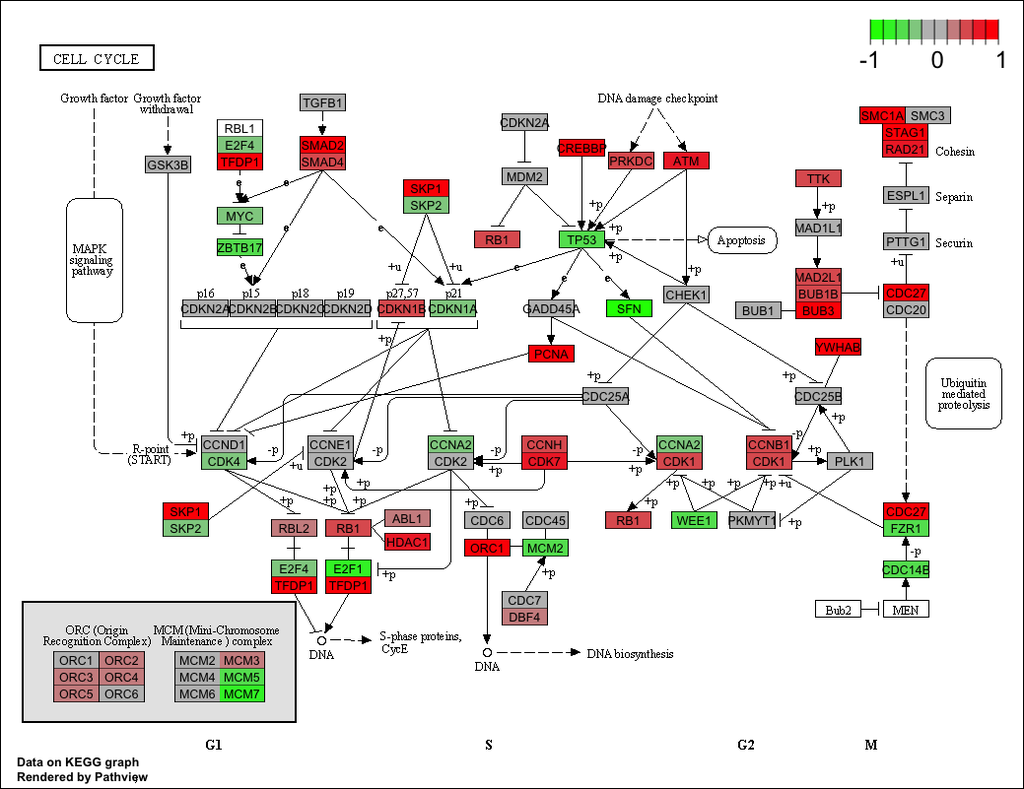

```r
img2_path <- "hsa04110.gse16873.2layer.png"
img2 <- readPNG(img2_path, native = TRUE, info = TRUE)
include_graphics(img2_path)
```

```r
###   graphviz has more control over nodes and edges in the same layer
pv.out <- pathview(gene.data = gse16873.d[, 1], pathway.id = demo.paths$sel.paths[i],
                   species = "hsa", out.suffix = "gse16873", kegg.native = F,
                   sign.pos = demo.paths$spos[i])
```

```
## Info: Working in directory /Users/deepthi/pathview_code
```

```
## Info: Writing image file hsa04110.gse16873.pdf
```

```r
library(pathview)
?pathview

dim(pv.out$plot.data.gene)
```

```
## [1] 92 10
```

```r
head(pv.out$plot.data.gene)
```

```
##   kegg.names labels                            all.mapped type   x   y width
## 4       1029 CDKN2A                                  1029 gene 532 124    46
## 5      51343   FZR1                                 51343 gene 919 536    46
## 6       4171   MCM2         4171,4172,4173,4174,4175,4176 gene 553 556    46
## 7       4998   ORC1       4998,4999,5000,5001,23594,23595 gene 494 556    46
## 8        996  CDC27 996,8697,8881,10393,25847,29882,51433 gene 919 297    46
## 9        996  CDC27 996,8697,8881,10393,25847,29882,51433 gene 919 519    46
##   height   mol.data mol.col
## 4     17  0.1291987 #BEBEBE
## 5     17 -0.4043256 #5FDF5F
## 6     17 -0.4202181 #5FDF5F
## 7     17  0.9864873 #FF0000
## 8     17  1.1811525 #FF0000
## 9     17  1.1811525 #FF0000
```

```r
###  graphviz.2layer
pv.out <- pathview(gene.data = gse16873.d[, 1], pathway.id = demo.paths$sel.paths[i], species = "hsa", out.suffix = "gse16873.2layer", kegg.native = F,
    sign.pos = demo.paths$spos[i], same.layer = F)
```

```
## Info: Working in directory /Users/deepthi/pathview_code
```

```
## Info: Writing image file hsa04110.gse16873.2layer.pdf
```

```r
###  split
pv.out <- pathview(gene.data = gse16873.d[, 1], pathway.id = demo.paths$sel.paths[i],
    species = "hsa", out.suffix = "gse16873.split", kegg.native = F,
    sign.pos = demo.paths$spos[i], split.group = T)
```

```
## Info: Working in directory /Users/deepthi/pathview_code
```

```
## Info: Writing image file hsa04110.gse16873.split.pdf
```

```r
dim(pv.out$plot.data.gene)
```

```
## [1] 92 10
```

```r
head(pv.out$plot.data.gene)
```

```
##   kegg.names labels                            all.mapped type   x   y width
## 4       1029 CDKN2A                                  1029 gene 532 124    46
## 5      51343   FZR1                                 51343 gene 919 536    46
## 6       4171   MCM2         4171,4172,4173,4174,4175,4176 gene 553 556    46
## 7       4998   ORC1       4998,4999,5000,5001,23594,23595 gene 494 556    46
## 8        996  CDC27 996,8697,8881,10393,25847,29882,51433 gene 919 297    46
## 9        996  CDC27 996,8697,8881,10393,25847,29882,51433 gene 919 519    46
##   height   mol.data mol.col
## 4     17  0.1291987 #BEBEBE
## 5     17 -0.4043256 #5FDF5F
## 6     17 -0.4202181 #5FDF5F
## 7     17  0.9864873 #FF0000
## 8     17  1.1811525 #FF0000
## 9     17  1.1811525 #FF0000
```

```r
### expanded
pv.out <- pathview(gene.data = gse16873.d[, 1], pathway.id = demo.paths$sel.paths[i],
    species = "hsa", out.suffix = "gse16873.split.expanded", kegg.native = F,
    sign.pos = demo.paths$spos[i], split.group = T, expand.node = T)
```

```
## Info: Working in directory /Users/deepthi/pathview_code
```

```
## Info: Writing image file hsa04110.gse16873.split.expanded.pdf
```

```r
dim(pv.out$plot.data.gene)
```

```
## [1] 124  10
```

```r
head(pv.out$plot.data.gene)
```

```
##           kegg.names labels all.mapped type   x   y width height    mol.data
## hsa:1029        1029 CDKN2A       1029 gene 532 124    46     17  0.12919874
## hsa:51343      51343   FZR1      51343 gene 919 536    46     17 -0.40432563
## hsa:4171        4171   MCM2       4171 gene 553 556    46     17  0.17968149
## hsa:4172        4172   MCM3       4172 gene 553 556    46     17  0.33149955
## hsa:4173        4173   MCM4       4173 gene 553 556    46     17  0.06996779
## hsa:4174        4174   MCM5       4174 gene 553 556    46     17 -0.42874682
##           mol.col
## hsa:1029  #BEBEBE
## hsa:51343 #5FDF5F
## hsa:4171  #BEBEBE
## hsa:4172  #CE8F8F
## hsa:4173  #BEBEBE
## hsa:4174  #5FDF5F
```

```r
### dataPrep.sim.cpd
sim.cpd.data=sim.mol.data(mol.type="cpd", nmol=3000)
data(cpd.simtypes)

##Data integration

#### gene_cpd.data
i <- 3
print(demo.paths$sel.paths[i])
```

```
## [1] "00640"
```

```r
pv.out <- pathview(gene.data = gse16873.d[, 1], cpd.data = sim.cpd.data,
    pathway.id = demo.paths$sel.paths[i], species = "hsa", out.suffix = "gse16873.cpd",keys.align = "y", kegg.native = T, key.pos = demo.paths$kpos1[i])
```

```
## Info: Working in directory /Users/deepthi/pathview_code
```

```
## Info: Writing image file hsa00640.gse16873.cpd.png
```

[figure not shown]

```r
img3_path <- "hsa00640.gse16873.cpd.png"
img3 <- readPNG(img3_path, native = TRUE, info = TRUE)
include_graphics(img3_path)
```

```r
str(pv.out)
```

```
## List of 2
##  $ plot.data.gene:'data.frame':  25 obs. of  10 variables:
##   ..$ kegg.names: chr [1:25] "4329" "31" "23417" "18" ...
##   ..$ labels    : chr [1:25] "ALDH6A1" "ACACA" "MLYCD" "ABAT" ...
##   ..$ all.mapped: chr [1:25] "4329" "31,32" "23417" "18" ...
##   ..$ type      : chr [1:25] "gene" "gene" "gene" "gene" ...
##   ..$ x         : num [1:25] 159 159 159 276 377 ...
##   ..$ y         : num [1:25] 325 252 204 378 327 409 494 390 390 229 ...
##   ..$ width     : num [1:25] 46 46 46 46 46 46 46 46 46 46 ...
##   ..$ height    : num [1:25] 17 17 17 17 17 17 17 17 17 17 ...
##   ..$ mol.data  : num [1:25] 0.747 -0.483 -0.251 2.785 0.77 ...
##   ..$ mol.col   : chr [1:25] "#EF3030" "#5FDF5F" "#8FCE8F" "#FF0000" ...
##  $ plot.data.cpd :'data.frame':  48 obs. of  10 variables:
##   ..$ kegg.names: chr [1:48] "C00222" "C00804" "C01013" "C00099" ...
##   ..$ labels    : chr [1:48] "C00222" "C00804" "C01013" "C00099" ...
##   ..$ all.mapped: chr [1:48] "" "C00804" "" "C00099" ...
##   ..$ type      : chr [1:48] "compound" "compound" "compound" "compound" ...
##   ..$ x         : num [1:48] 225 222 324 325 222 ...
##   ..$ y         : num [1:48] 327 449 327 388 228 105 105 105 157 228 ...
##   ..$ width     : num [1:48] 8 8 8 8 8 8 8 8 8 8 ...
##   ..$ height    : num [1:48] 8 8 8 8 8 8 8 8 8 8 ...
##   ..$ mol.data  : num [1:48] NA 0.564 NA 0.871 NA ...
##   ..$ mol.col   : chr [1:48] "#FFFFFF" "#DFDF5F" "#FFFFFF" "#FFFF00" ...
```

```r
head(pv.out$plot.data.cpd)
```

```
##    kegg.names labels all.mapped     type   x   y width height  mol.data mol.col
## 30     C00222 C00222            compound 225 327     8      8        NA #FFFFFF
## 31     C00804 C00804     C00804 compound 222 449     8      8 0.5643663 #DFDF5F
## 32     C01013 C01013            compound 324 327     8      8        NA #FFFFFF
## 33     C00099 C00099     C00099 compound 325 388     8      8 0.8706309 #FFFF00
## 36     C00083 C00083            compound 222 228     8      8        NA #FFFFFF
## 84     C00109 C00109            compound 806 105     8      8        NA #FFFFFF
```

```r
##### graphviz.gene_cpd.data
pv.out <- pathview (gene.data = gse16873.d[, 1], cpd.data = sim.cpd.data,
    pathway.id = demo.paths$sel.paths[i], species = "hsa", out.suffix = "gse16873.cpd", keys.align = "y", kegg.native = F, key.pos = demo.paths$kpos2[i],
    sign.pos = demo.paths$spos[i], cpd.lab.offset = demo.paths$offs[i])
```

```
## Info: Working in directory /Users/deepthi/pathview_code
```

```
## Info: Writing image file hsa00640.gse16873.cpd.pdf
```

```r
#######sim.cpd.data2
set.seed(10)
sim.cpd.data2 = matrix(sample(sim.cpd.data, 18000,
    replace = T), ncol = 6)
rownames(sim.cpd.data2) = names(sim.cpd.data)
colnames(sim.cpd.data2) = paste("exp", 1:6, sep = "")
head(sim.cpd.data2, 3)
```

```
##             exp1         exp2       exp3       exp4       exp5       exp6
## C00232 0.5223972 -0.357041809 -0.4605917  0.3195047 -0.5248542 -0.9424900
## C01881 0.1263224  0.003949847 -0.3649231 -1.0199797 -2.4024820  0.5059053
## C02424 2.0966844  0.571453538  0.2148428  0.3204217 -1.9725272  1.1587705
```

```r
### multisample.gene_cpd.data
### KEGG view
pv.out <- pathview(gene.data = gse16873.d[, 1:3],
    cpd.data = sim.cpd.data2[, 1:2], pathway.id = demo.paths$sel.paths[i],
    species = "hsa", out.suffix = "gse16873.cpd.3-2s", keys.align = "y",
    kegg.native = T, match.data = F, multi.state = T, same.layer = T)
```

```
## Info: Working in directory /Users/deepthi/pathview_code
```

```
## Info: Writing image file hsa00640.gse16873.cpd.3-2s.multi.png
```

```r
head(pv.out$plot.data.cpd)
```

```
##    kegg.names labels all.mapped     type   x   y width height       exp1
## 30     C00222 C00222            compound 225 327     8      8         NA
## 31     C00804 C00804     C00804 compound 222 449     8      8 -0.7773255
## 32     C01013 C01013            compound 324 327     8      8         NA
## 33     C00099 C00099     C00099 compound 325 388     8      8 -0.5785750
## 36     C00083 C00083            compound 222 228     8      8         NA
## 84     C00109 C00109            compound 806 105     8      8         NA
##          exp2 exp1.col exp2.col
## 30         NA  #FFFFFF  #FFFFFF
## 31 -0.1306727  #3030EF  #BEBEBE
## 32         NA  #FFFFFF  #FFFFFF
## 33  0.6952993  #5F5FDF  #EFEF30
## 36         NA  #FFFFFF  #FFFFFF
## 84         NA  #FFFFFF  #FFFFFF
```

```r
### KEGG view data match
pv.out <- pathview(gene.data = gse16873.d[, 1:3],
    cpd.data = sim.cpd.data2[, 1:2], pathway.id = demo.paths$sel.paths[i],
    species = "hsa", out.suffix = "gse16873.cpd.3-2s.match",
    keys.align = "y", kegg.native = T, match.data = T, multi.state = T,
    same.layer = T)
```

```
## Info: Working in directory /Users/deepthi/pathview_code
```

```
## Info: Writing image file hsa00640.gse16873.cpd.3-2s.match.multi.png
```

```r
#### graphviz view
pv.out <- pathview(gene.data = gse16873.d[, 1:3],
    cpd.data = sim.cpd.data2[, 1:2], pathway.id = demo.paths$sel.paths[i],
    species = "hsa", out.suffix = "gse16873.cpd.3-2s", keys.align = "y",
    kegg.native = F, match.data = F, multi.state = T, same.layer = T,
    key.pos = demo.paths$kpos2[i], sign.pos = demo.paths$spos[i])
```

```
## Info: Working in directory /Users/deepthi/pathview_code
```

```
## Info: Writing image file hsa00640.gse16873.cpd.3-2s.multi.pdf
```

```r
###### multisample.gene_cpd.data.separate (eval=FALSE)
#plot samples/states separately
 pv.out <- pathview(gene.data = gse16873.d[, 1:3],
     cpd.data = sim.cpd.data2[, 1:2], pathway.id = demo.paths$sel.paths[i],
     species = "hsa", out.suffix = "gse16873.cpd.3-2s", keys.align = "y",
     kegg.native = T, match.data = F, multi.state = F, same.layer = T)
```

```
## Info: Working in directory /Users/deepthi/pathview_code
```

```
## Info: Writing image file hsa00640.gse16873.cpd.3-2s.DCIS_1.png
```

```
## Info: Writing image file hsa00640.gse16873.cpd.3-2s.DCIS_2.png
```

```
## Info: Writing image file hsa00640.gse16873.cpd.3-2s.DCIS_3.png
```

```r
######multisample.gene_cpd.data.2layer (eval = FALSE)
 pv.out <- pathview(gene.data = gse16873.d[, 1:3],
     cpd.data = sim.cpd.data2[, 1:2], pathway.id = demo.paths$sel.paths[i],
     species = "hsa", out.suffix = "gse16873.cpd.3-2s.2layer",
     keys.align = "y", kegg.native = T, match.data = F, multi.state = T,
     same.layer = F)
```

```
## Info: Working in directory /Users/deepthi/pathview_code
```

```
## Info: Writing image file hsa00640.gse16873.cpd.3-2s.2layer.multi.png
```

```r
########discrete.gene_cpd.data
 require(org.Hs.eg.db)
gse16873.t <- apply(gse16873.d, 1, function(x) t.test(x,
    alternative = "two.sided")$p.value)
sel.genes <- names(gse16873.t)[gse16873.t < 0.1]
sel.cpds <- names(sim.cpd.data)[abs(sim.cpd.data) > 0.5]
pv.out <- pathview(gene.data = sel.genes, cpd.data = sel.cpds,
    pathway.id = demo.paths$sel.paths[i], species = "hsa", out.suffix = "sel.genes.sel.cpd",
    keys.align = "y", kegg.native = T, key.pos = demo.paths$kpos1[i],
    limit = list(gene = 5, cpd = 2), bins = list(gene = 5, cpd = 2),
    na.col = "gray", discrete = list(gene = T, cpd = T))
```

```
## Info: Working in directory /Users/deepthi/pathview_code
```

```
## Info: Writing image file hsa00640.sel.genes.sel.cpd.png
```

```r
pv.out <- pathview(gene.data = sel.genes, cpd.data = sim.cpd.data,
    pathway.id = demo.paths$sel.paths[i], species = "hsa", out.suffix =   "sel.genes.cpd",keys.align = "y", kegg.native = T, key.pos = demo.paths$kpos1[i],
    limit = list(gene = 5, cpd = 1), bins = list(gene = 5, cpd = 10),
    na.col = "gray", discrete = list(gene = T, cpd = F))
```

```
## Info: Working in directory /Users/deepthi/pathview_code
```

```
## Info: Writing image file hsa00640.sel.genes.cpd.png
```

```r
######### gene.ensprot_cpd.cas
cpd.cas <- sim.mol.data(mol.type = "cpd", id.type = cpd.simtypes[2],
    nmol = 10000)
```

```
## Note: "CAS Registry Number" has only 4643 unique IDs!
```

```r
gene.ensprot <- sim.mol.data(mol.type = "gene", id.type = gene.idtype.list[4],
    nmol = 50000)
```

```
## Note: "ENSEMBLPROT" has only 21951 unique IDs!
```

```r
pv.out <- pathview(gene.data = gene.ensprot, cpd.data = cpd.cas,
    gene.idtype = gene.idtype.list[4], cpd.idtype = cpd.simtypes[2],
    pathway.id = demo.paths$sel.paths[i], species = "hsa", same.layer = T,
    out.suffix = "gene.ensprot.cpd.cas", keys.align = "y", kegg.native = T,
    key.pos = demo.paths$kpos2[i], sign.pos = demo.paths$spos[i],
    limit = list(gene = 3, cpd = 3), bins = list(gene = 6, cpd = 6))
```

```
## Note: multiple compounds may map to a input ID, only the first one kept!
```

```
## Info: Working in directory /Users/deepthi/pathview_code
```

```
## Info: Writing image file hsa00640.gene.ensprot.cpd.cas.png
```

```r
####### gene.ensprot_cpd.cas.manual.map
id.map.cas <- cpdidmap(in.ids = names(cpd.cas), in.type = cpd.simtypes[2],
    out.type = "KEGG COMPOUND accession")
```

```
## Note: multiple compounds may map to a input ID, only the first one kept!
```

```r
     cpd.kc <- mol.sum(mol.data = cpd.cas, id.map = id.map.cas)
      id.map.ensprot <- id2eg(ids = names(gene.ensprot),
    category = gene.idtype.list[4], org = "Hs")
    gene.entrez <- mol.sum(mol.data = gene.ensprot, id.map = id.map.ensprot)
pv.out <- pathview(gene.data = gene.entrez, cpd.data = cpd.kc,
    pathway.id = demo.paths$sel.paths[i], species = "hsa", same.layer = T,
    out.suffix = "gene.entrez.cpd.kc", keys.align = "y", kegg.native = T,
    key.pos = demo.paths$kpos2[i], sign.pos = demo.paths$spos[i],
    limit = list(gene = 3, cpd = 3), bins = list(gene = 6, cpd = 6))
```

```
## Info: Working in directory /Users/deepthi/pathview_code
```

```
## Info: Writing image file hsa00640.gene.entrez.cpd.kc.png
```

```r
#######korg
data(korg)
head(korg)
```

```
##      ktax.id  tax.id  kegg.code scientific.name
## [1,] "T01001" "9606"  "hsa"     "Homo sapiens"
## [2,] "T01005" "9598"  "ptr"     "Pan troglodytes"
## [3,] "T02283" "9597"  "pps"     "Pan paniscus"
## [4,] "T02442" "9595"  "ggo"     "Gorilla gorilla gorilla"
## [5,] "T01416" "9601"  "pon"     "Pongo abelii"
## [6,] "T03265" "61853" "nle"     "Nomascus leucogenys"
##      common.name                     entrez.gnodes kegg.geneid ncbi.geneid
## [1,] "human"                         "1"           "374659"    "374659"
## [2,] "chimpanzee"                    "1"           "474020"    "474020"
## [3,] "bonobo"                        "1"           "100989900" "100989900"
## [4,] "western lowland gorilla"       "1"           "101125212" "101125212"
## [5,] "Sumatran orangutan"            "1"           "100172878" "100172878"
## [6,] "northern white-cheeked gibbon" "1"           "105739221" "105739221"
##      ncbi.proteinid uniprot
## [1,] "NP_001273380" "Q8N4P3"
## [2,] "XP_001140087" "Q1XHV8"
## [3,] "XP_003811308" NA
## [4,] "XP_018886437" "G3QNH0"
## [5,] "NP_001125944" "Q5R9G0"
## [6,] "XP_012359712" "G1RK33"
```

```r
#number of species which use Entrez Gene as the default ID
sum(korg[,"entrez.gnodes"]=="1",na.rm=T)
```

```
## [1] 204
```

```r
#number of species which use other ID types or none as the default ID
sum(korg[,"entrez.gnodes"]=="0",na.rm=T)
```

```
## [1] 5041
```

```r
#new from 2017: most species which do not have Entrez Gene annotation any more
na.idx=is.na(korg[,"ncbi.geneid"])
sum(na.idx)
```

```
## [1] 4674
```

```r
###### bods_gene.idtype.list
data(bods)
bods
```

```
##       package             species               kegg code id.type
##  [1,] "org.Ag.eg.db"      "Anopheles"           "aga"     "eg"
##  [2,] "org.At.tair.db"    "Arabidopsis"         "ath"     "tair"
##  [3,] "org.Bt.eg.db"      "Bovine"              "bta"     "eg"
##  [4,] "org.Ce.eg.db"      "Worm"                "cel"     "eg"
##  [5,] "org.Cf.eg.db"      "Canine"              "cfa"     "eg"
##  [6,] "org.Dm.eg.db"      "Fly"                 "dme"     "eg"
##  [7,] "org.Dr.eg.db"      "Zebrafish"           "dre"     "eg"
##  [8,] "org.EcK12.eg.db"   "E coli strain K12"   "eco"     "eg"
##  [9,] "org.EcSakai.eg.db" "E coli strain Sakai" "ecs"     "eg"
## [10,] "org.Gg.eg.db"      "Chicken"             "gga"     "eg"
## [11,] "org.Hs.eg.db"      "Human"               "hsa"     "eg"
## [12,] "org.Mm.eg.db"      "Mouse"               "mmu"     "eg"
## [13,] "org.Mmu.eg.db"     "Rhesus"              "mcc"     "eg"
## [14,] "org.Pf.plasmo.db"  "Malaria"             "pfa"     "orf"
## [15,] "org.Pt.eg.db"      "Chimp"               "ptr"     "eg"
## [16,] "org.Rn.eg.db"      "Rat"                 "rno"     "eg"
## [17,] "org.Sc.sgd.db"     "Yeast"               "sce"     "orf"
## [18,] "org.Ss.eg.db"      "Pig"                 "ssc"     "eg"
## [19,] "org.Xl.eg.db"      "Xenopus"             "xla"     "eg"
```

```r
data(gene.idtype.list)
gene.idtype.list
```

```
##  [1] "SYMBOL"       "GENENAME"     "ENSEMBL"      "ENSEMBLPROT"  "UNIGENE"
##  [6] "UNIPROT"      "ACCNUM"       "ENSEMBLTRANS" "REFSEQ"       "ENZYME"
## [11] "TAIR"         "PROSITE"      "ORF"
```

```r
###### eco.dat.Kegg
eco.dat.entrez <-sim.mol.data(mol.type="gene",id.type="entrez",species="eco",
                               nmol=3000)
head(eco.dat.entrez)
```

```
##     948629     945263     948265     948536     948973     947881
## -0.2516281  0.3116743  0.9873035 -1.5734323  1.8890136  0.2399454
```

```r
pv.out <- pathview(gene.data = eco.dat.entrez, gene.idtype="entrez",         pathway.id="00640", species = "eco", out.suffix = "eco.entrez", kegg.native = T,   same.layer=T)
```

```
## Info: Getting gene ID data from KEGG...
```

```
## Info: Done with data retrieval!
```

```
## Info: Working in directory /Users/deepthi/pathview_code
```

```
## Info: Writing image file eco00640.eco.entrez.png
```

```r
#######  eco.dat.symbol (eval = FALSE)
egid.eco=eg2id(names(eco.dat.entrez), category="symbol", pkg="org.EcK12.eg.db")
```

```
## [1] "Note: 198 of 3000 unique input IDs unmapped."
```

```r
## eco.dat.symbol <- eco.dat.entrez
## names(eco.dat.symbol) <- egid.eco[,2]
## head(eco.dat.kegg)
## pv.out <- pathview(gene.data = eco.dat.symbol, gene.idtype="symbol",
##     pathway.id = "00640", species = "eco", out.suffix = "eco.symbol.2layer",
##     kegg.native = T, same.layer=F)
```

## Reference

Luo, Weijun, and Cory Brouwer. 2013. “Pathview: an R/Bioconductor package for pathway-based data integration and visualization.” *Bioinformatics* 29 (14): 1830–1. https://doi.org/10.1093/bioinformatics/btt285.